# Patient Characteristics in Determing Clinical Outcomes Among COVID-19 Patients

Sri Denduluri, Ph.D

### Overview

According to the published literature, COVID-19 is disproportionately affecting gender, and racial minorities but patient-level observations of ICU admission, ventilator requirement and even mortality by patient characteristics are very limited. The objective of this study is to systematically determine what patient characteristics including race are associated with COVID-19 outcomes.

### Introduction

Coronavirus disease is caused by Severe Acute Respiratory Syndrome Coronavirus 2 (SARS-CoV-2) and was first detected in Wuhan, China in 2019. The disease has impacted over 150 countries and emerged as a global pandemic infecting over 1.5 million patients in the United States as of early June 2020. Since the U.S has become the epicenter of this crisis, multiple studies were undertaken to study the disease manifestations and patient outcomes to show the impact of this crisis nationwide. There is a sharp rise of COVID-19 infections in U.S. and along with population concerns there has also emerged awareness regarding the COVID-19 infections disproportionately impacting racial/ethnic minorities. Multiple studies have been reported that people who belong certain racial and ethnic groups have higher rates of hospitalization. Earlier studies have also reported that people who are aged and smoke and those who have had existing co-morbid conditions are mostly likely to be affected by COVID-19. These groups will have higher infection rates, disease severity and even mortality. Despite the early studies, patient-level studies with appropriate co-morbid conditions, patient characteristics and clinical outcomes differ by race/ethnicity among hospitalized patients with COVID-19 are lacking.

### Study Population:

The de-identified data sets used for this project were pulled from the Penn Medicine’s Clarity Database on patients who were visited to one of the hospitals at Penn Medicine for COVID-19 test. The study has the approval by the Institutional Review Board at the University of Pennsylvania as part of Division of Cardiovascular Medicine blanket-IRB approval.

Using SQL-queries, I obtained two data files. First I have pulled the patients who have had COVID-19 confirmed-positive (positive). For these patients, I have obtained the demographics and other-related clinical information that were related to this project.. Demographics and clinical information included Age (in years) , Race (Black, White), Gender (Male Yes/No), Smoking Status (Tobacco exposure Yes/No), ICU admission (Yes/No), Ventilator used (Yes/No) and Deceased (Yes/No)) as a first data set. A second file contained any documented history of obesity for these same patients.

All the patient identifiers were carefully removed and replaced with a unique random number to link the data between the two data sets. Most of the variables were represented as categorical variables (yes/no) and age was represented as a numeric variable. A two Excel CSV files were created from the above data sets namely COVID_Pats.csv and COVID_Comorb.csv and have been loaded into R as data frames called Pat_Demo and Pat_Comorb respectively.

The following R packages and libraries were used in this study:

[output not shown]

At first, the patient data was imported from their respective csv files and they were imported into two data frames.

````
```r
#Data read from CSV files
Pat_Demo = read.csv("C:/Users/Administrator/Downloads/COVID_Pats1a.csv",header = TRUE, stringsAsFactors = TRUE)

Pat_Comorb = read.csv("C:/Users/Administrator/Downloads/COVID_Comorb1.csv",header = TRUE, stringsAsFactors = TRUE)
```
````

The summary views of the two data sets that were imported into two data frames were shown below:

````
```r
str(Pat_Demo)
```

```
## 'data.frame':    3697 obs. of  9 variables:
##  $ Random_Number  : int  306 1640 1735 2267 3452 3832 4324 5240 5267 5696 ...
##  $ Age            : int  32 74 33 68 27 35 32 33 51 52 ...
##  $ Race           : Factor w/ 2 levels "Black","White": 2 2 1 1 1 2 1 1 1 1 ...
##  $ Gender         : Factor w/ 2 levels "Female","Male": 1 2 2 1 2 1 2 1 1 2 ...
##  $ Smoking_Status : Factor w/ 3 levels "N","Nt Asked",..: 1 2 3 1 3 1 3 1 3 3 ...
##  $ ICU_Dept_YN    : Factor w/ 2 levels "N","Y": 1 1 1 2 1 1 1 1 2 1 ...
##  $ Ventilator_YN  : Factor w/ 2 levels "N","Y": 1 1 1 1 1 1 1 1 2 1 ...
##  $ Category       : Factor w/ 1 level "Confirmed": 1 1 1 1 1 1 1 1 1 1 ...
##  $ Deceased_Status: Factor w/ 2 levels "N","Y": 1 1 1 1 1 1 1 1 2 1 ...
```

```r
str(Pat_Comorb)
```

```
## 'data.frame':    5762 obs. of  2 variables:
##  $ Random_Number: int  377713 378047 378318 378348 379668 380250 380318 380774 380980 381026 ...
##  $ Obesity      : Factor w/ 2 levels "N","Y": 1 2 1 1 1 1 1 1 1 1 ...
```
````

The two extracted data frames were then merged into a single data frame which was used for further analyses and the summary view of the final data set was shown below.

```r
# Merged Data Set
    Pat_Merged_Data <- merge(Pat_Demo, Pat_Comorb)
    str(Pat_Merged_Data)
```

```
## 'data.frame':    3712 obs. of  10 variables:
##  $ Random_Number  : int  306 1640 1735 2267 3452 3832 4324 5240 5267 5696 ...
##  $ Age            : int  32 74 33 68 27 35 32 33 51 52 ...
##  $ Race           : Factor w/ 2 levels "Black","White": 2 2 1 1 1 2 1 1 1 1 ...
##  $ Gender         : Factor w/ 2 levels "Female","Male": 1 2 2 1 2 1 2 1 1 2 ...
##  $ Smoking_Status : Factor w/ 3 levels "N","Nt Asked",..: 1 2 3 1 3 1 3 1 3 3 ...
##  $ ICU_Dept_YN    : Factor w/ 2 levels "N","Y": 1 1 1 2 1 1 1 1 2 1 ...
##  $ Ventilator_YN  : Factor w/ 2 levels "N","Y": 1 1 1 1 1 1 1 1 2 1 ...
##  $ Category       : Factor w/ 1 level "Confirmed": 1 1 1 1 1 1 1 1 1 1 ...
##  $ Deceased_Status: Factor w/ 2 levels "N","Y": 1 1 1 1 1 1 1 1 2 1 ...
##  $ Obesity        : Factor w/ 2 levels "N","Y": 1 1 1 2 1 2 1 2 1 2 ...
```

Some of the variable names were re-named in the final data set and the summary view is shown below:

```r
#Creating a new data set for analysis
COVID.clean <- Pat_Merged_Data %>%
        dplyr::select(Age,Race,Gender,Smoking_Status,ICU_Dept_YN,Ventilator_YN,Category,Deceased_Status,
        Obesity) %>%
        rename(age = Age,race = Race,gender= Gender,smoking.status = Smoking_Status,category = Category,
            deceased.status = Deceased_Status, icu=ICU_Dept_YN, ventilator = Ventilator_YN, obesity = Obesity)

  str(COVID.clean)
```

```
## 'data.frame':    3712 obs. of  9 variables:
##  $ age            : int  32 74 33 68 27 35 32 33 51 52 ...
##  $ race           : Factor w/ 2 levels "Black","White": 2 2 1 1 1 2 1 1 1 1 ...
##  $ gender         : Factor w/ 2 levels "Female","Male": 1 2 2 1 2 1 2 1 1 2 ...
##  $ smoking.status : Factor w/ 3 levels "N","Nt Asked",..: 1 2 3 1 3 1 3 1 3 3 ...
##  $ icu            : Factor w/ 2 levels "N","Y": 1 1 1 2 1 1 1 1 2 1 ...
##  $ ventilator     : Factor w/ 2 levels "N","Y": 1 1 1 1 1 1 1 1 2 1 ...
##  $ category       : Factor w/ 1 level "Confirmed": 1 1 1 1 1 1 1 1 1 1 ...
##  $ deceased.status: Factor w/ 2 levels "N","Y": 1 1 1 1 1 1 1 1 2 1 ...
##  $ obesity        : Factor w/ 2 levels "N","Y": 1 1 1 2 1 2 1 2 1 2 ...
```

In addition to Yes/No, the smoking status variable also contains information such as ’Not Asked", so a new data set was created of patients who answered Yes/No to evaluate the effects of smoking on the outcomes.

```r
  #Data set for smoking Yes/No
smoking_set <- COVID.clean %>%
    filter(smoking.status == 'Y' | smoking.status == 'N')
```

The logistic regression to model the outcome variables of ICU admission, Ventilator use and Deceased Status were used since these outcomes are Boolean. Each of the predictor (independent) variables are either numeric (age) or Boolean (all the others). Initially, univariate models for each of the outcome variables were constructed to look for significant relationship. A multivariate model for each outcome variable containing all independent variables which were significant to the level of P<0.10 in univariate models were generated for further analyses.

### Results

```r
  # make dataset with a few variables to summarize
  Pat_char <- COVID.clean %>% select(age, race, gender, obesity,smoking.status,icu,ventilator,deceased.status)

  # summarize the data
  Pat_char_Table <- tbl_summary(Pat_char)
  Pat_char_Table
```

| **Characteristic** | **N = 3,712**<sup>1</sup> |
| --- | --- |
| age | 55 (35, 70) |
| race |  |
| Black | 2,437 (66%) |
| White | 1,275 (34%) |
| gender |  |
| Female | 2,068 (56%) |
| Male | 1,644 (44%) |
| obesity |  |
| N | 2,907 (78%) |
| Y | 805 (22%) |
| smoking.status |  |
| N | 1,892 (51%) |
| Nt Asked | 652 (18%) |
| Y | 1,168 (31%) |
| icu |  |
| N | 3,256 (88%) |
| Y | 456 (12%) |
| ventilator |  |
| N | 3,355 (90%) |
| Y | 357 (9.6%) |
| deceased.status |  |
| N | 3,346 (90%) |
| Y | 366 (9.9%) |

<sup>*1*</sup> Statistics presented: Median (IQR); n (%)

The average patient age of the cohort based on the race was shown below. The average age among white population was 60 and within African population, the average age was 50 respectively.

```r
    ##mean patient age based on race
  Avg_age <-COVID.clean  %>%
  group_by(race) %>%
  summarize(AvG_Pat_Age = mean(as.numeric(age), na.rm=TRUE), counts = n()) %>%
  arrange(desc(AvG_Pat_Age))
```

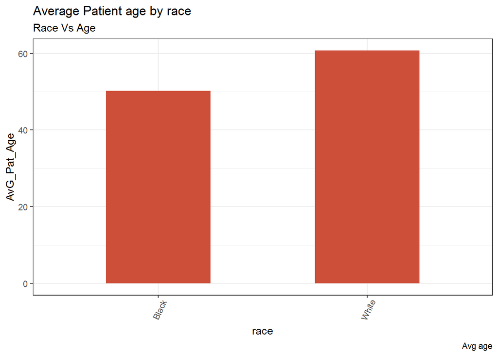

```r
    #average length of stay of patients by race
    theme_set(theme_bw())
    ggplot(Avg_age, aes(x = race, y = AvG_Pat_Age)) +
      geom_bar(stat="identity", width=.5, fill="tomato3") +
      labs(title="Average Patient age by race",
           subtitle="Race Vs Age",
           caption="Avg age") +
      theme(axis.text.x = element_text(angle=65, vjust=0.6))
```

A box-plot graph has been created to show the relationship between ICU admission and age and it is quite evident that there was correlation exists between age and ICU admission.

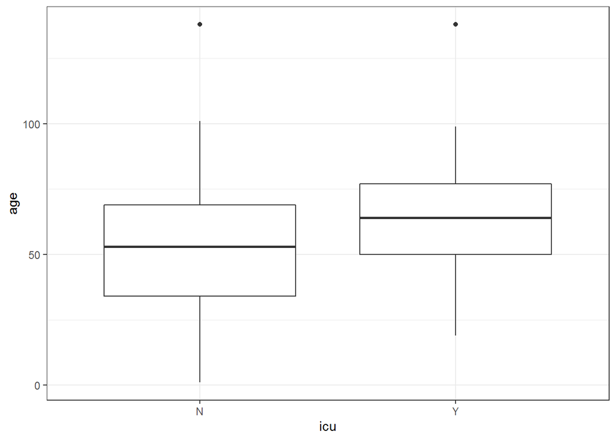

```r
#For outcome ICU versus predictor age
    ggplot(COVID.clean, aes(x = icu, y = age)) +
        geom_boxplot()
```

### Chi-Square anaysis and contingency tables

The chi-square analysis for ICU and gender shows a greater exists between the variables studied with a chi-square value of 7.139 with a highly significant p-value of 0.008 as shown below.

```r
  #ICU
  # print minimal cross table with labels, total col/row highlighted
  sjt.xtab(COVID.clean$icu, COVID.clean$gender, show.cell.prc = FALSE, emph.total = TRUE)
```

| icu | gender |  | Total |  |
| --- | --- | --- | --- | --- |
|  | Female | Male |  |  |
| N | 1841 | 1415 |  | 3256 |
| Y | 227 | 229 | 456 |  |
| Total | 2068 | 1644 | 3712 |  |

A similar association exists among ICU and race and obesity with chi-square values of 2.793, 15.654 and with p-value of less than or equal to 0.09 respectively as shown in the following contingency tables. For smoking status, Fisher’s p-value was 0.002.

```r
  #ICU
  sjt.xtab(COVID.clean$icu, COVID.clean$race, show.cell.prc = FALSE, emph.total = TRUE)
```

| icu | race |  | Total |  |
| --- | --- | --- | --- | --- |
|  | Black | White |  |  |
| N | 2154 | 1102 |  | 3256 |
| Y | 283 | 173 | 456 |  |
| Total | 2437 | 1275 | 3712 |  |

```r
  sjt.xtab(COVID.clean$icu, COVID.clean$obesity, show.cell.prc = FALSE, emph.total = TRUE)
```

| icu | obesity |  | Total |  |
| --- | --- | --- | --- | --- |
|  | N | Y |  |  |
| N | 2583 | 673 |  | 3256 |
| Y | 324 | 132 | 456 |  |
| Total | 2907 | 805 | 3712 |  |

```r
  sjt.xtab(smoking_set$icu, smoking_set$smoking.status, show.cell.prc = FALSE, emph.total = TRUE)
```

| icu | smoking.status |  |  | Total |  |
| --- | --- | --- | --- | --- | --- |
|  | N | Nt Asked | Y |  |  |
| N | 1677 | 0 | 987 |  | 2664 |
| Y | 215 | 0 | 181 | 396 |  |
| Total | 1892 | 0 | 1168 | 3060 |  |

The same analysis for ventilator against gender, race, obesity and smoking status were done and it reveals except race all the three remaining variables have a greater and significant association with the ventilator use (p<0.08). The p-value for race was 0.404 as shown below:

```r
 #Ventilator
    # print minimal cross table with labels, total col/row highlighted
  sjt.xtab(COVID.clean$ventilator, COVID.clean$gender, show.cell.prc = FALSE, emph.total = TRUE)
```

| ventilator | gender |  | Total |  |
| --- | --- | --- | --- | --- |
|  | Female | Male |  |  |
| N | 1905 | 1450 |  | 3355 |
| Y | 163 | 194 | 357 |  |
| Total | 2068 | 1644 | 3712 |  |

```r
  sjt.xtab(COVID.clean$ventilator, COVID.clean$race, show.cell.prc = FALSE, emph.total = TRUE)
```

| ventilator | race |  | Total |  |
| --- | --- | --- | --- | --- |
|  | Black | White |  |  |
| N | 2195 | 1160 |  | 3355 |
| Y | 242 | 115 | 357 |  |
| Total | 2437 | 1275 | 3712 |  |

```r
  sjt.xtab(COVID.clean$ventilator, COVID.clean$obesity, show.cell.prc = FALSE, emph.total = TRUE)
```

| ventilator | obesity |  | Total |  |
| --- | --- | --- | --- | --- |
|  | N | Y |  |  |
| N | 2654 | 701 |  | 3355 |
| Y | 253 | 104 | 357 |  |
| Total | 2907 | 805 | 3712 |  |

```r
  sjt.xtab(smoking_set$ventilator, smoking_set$smoking.status, show.cell.prc = FALSE, emph.total = TRUE)
```

| ventilator | smoking.status |  |  | Total |  |
| --- | --- | --- | --- | --- | --- |
|  | N | Nt Asked | Y |  |  |
| N | 1727 | 0 | 1037 |  | 2764 |
| Y | 165 | 0 | 131 | 296 |  |
| Total | 1892 | 0 | 1168 | 3060 |  |

In contrast, the chi-square analysis on decease status against gender, race, obesity and smoking.status shows that only race and smoking status showed an association exist between the observed and expected as shown in the tables below.

```r
#deceased.status
    # print minimal cross table with labels, total col/row highlighted
  sjt.xtab(COVID.clean$deceased.status, COVID.clean$gender, show.cell.prc = FALSE, emph.total = TRUE)
```

| deceased.status | gender |  | Total |  |
| --- | --- | --- | --- | --- |
|  | Female | Male |  |  |
| N | 1875 | 1471 |  | 3346 |
| Y | 193 | 173 | 366 |  |
| Total | 2068 | 1644 | 3712 |  |

```r
  sjt.xtab(COVID.clean$deceased.status, COVID.clean$race, show.cell.prc = FALSE, emph.total = TRUE)
```

| deceased.status | race |  | Total |  |
| --- | --- | --- | --- | --- |
|  | Black | White |  |  |
| N | 2262 | 1084 |  | 3346 |
| Y | 175 | 191 | 366 |  |
| Total | 2437 | 1275 | 3712 |  |

```r
  sjt.xtab(COVID.clean$deceased.status, COVID.clean$obesity, show.cell.prc = FALSE, emph.total = TRUE)
```

| deceased.status | obesity |  | Total |  |
| --- | --- | --- | --- | --- |
|  | N | Y |  |  |
| N | 2612 | 734 |  | 3346 |
| Y | 295 | 71 | 366 |  |
| Total | 2907 | 805 | 3712 |  |

```r
  sjt.xtab(smoking_set$deceased.status, smoking_set$smoking.status, show.cell.prc = FALSE, emph.total = TRUE)
```

| deceased.status | smoking.status |  |  | Total |  |
| --- | --- | --- | --- | --- | --- |
|  | N | Nt Asked | Y |  |  |
| N | 1741 | 0 | 1021 |  | 2762 |
| Y | 151 | 0 | 147 | 298 |  |
| Total | 1892 | 0 | 1168 | 3060 |  |

### Univariate Analyses:

The univariate analysis of each predictor variable against the each outcome variable has been shown in the following tables. For ICU against age, the p-values for intercept and age were less than 0.001 showing they were very significant.

```r
model_age_i <- glm(formula= icu ~ age, data=COVID.clean, family=binomial)
    tab_model(model_age_i)
```

|  | icu |  |  |
| --- | --- | --- | --- |
| Predictors | Odds Ratios | CI | p |
| (Intercept) | 0.04 | 0.03 – 0.06 | **<0.001** |
| age | 1.02 | 1.02 – 1.03 | **<0.001** |
| Observations | 3712 |  |  |
| R<sup>2</sup> Tjur | 0.020 |  |  |

The univariate analysis for ICU against race,gender, obesity and smoking status were also significant meeting the threshold values (p<0.10). The p-values for race, gender, obesity and smoking status were 0.085, 0.007, 0.001 and 0.001 respectively.

```r
    model_r_i <- glm(formula= icu ~ race, data=COVID.clean, family=binomial)
    tab_model(model_r_i)
```

|  | icu |  |  |
| --- | --- | --- | --- |
| Predictors | Odds Ratios | CI | p |
| (Intercept) | 0.13 | 0.12 – 0.15 | **<0.001** |
| race [White] | 1.19 | 0.97 – 1.46 | 0.085 |
| Observations | 3712 |  |  |
| R<sup>2</sup> Tjur | 0.001 |  |  |

```r
    model_g_i <- glm(formula= icu ~ gender, data=COVID.clean, family=binomial)
     tab_model(model_g_i)
```

|  | icu |  |  |
| --- | --- | --- | --- |
| Predictors | Odds Ratios | CI | p |
| (Intercept) | 0.12 | 0.11 – 0.14 | **<0.001** |
| gender [Male] | 1.31 | 1.08 – 1.60 | **0.007** |
| Observations | 3712 |  |  |
| R<sup>2</sup> Tjur | 0.002 |  |  |

```r
    model_o_i <- glm(formula= icu ~ obesity, data=COVID.clean, family=binomial)
     tab_model(model_o_i)
```

|  | icu |  |  |
| --- | --- | --- | --- |
| Predictors | Odds Ratios | CI | p |
| (Intercept) | 0.13 | 0.11 – 0.14 | **<0.001** |
| obesity [Y] | 1.56 | 1.25 – 1.94 | **<0.001** |
| Observations | 3712 |  |  |
| R<sup>2</sup> Tjur | 0.004 |  |  |

```r
     model_smo_i <- glm(formula= icu ~ smoking.status, data=smoking_set, family=binomial)
     tab_model(model_smo_i)
```

|  | icu |  |  |
| --- | --- | --- | --- |
| Predictors | Odds Ratios | CI | p |
| (Intercept) | 0.13 | 0.11 – 0.15 | **<0.001** |
| smoking.status [Y] | 1.43 | 1.16 – 1.77 | **0.001** |
| Observations | 3060 |  |  |
| R<sup>2</sup> Tjur | 0.004 |  |  |

Unlike ICU, the univariate analysis for ventilator against each predictor variables, except race, all the other variables (age,gender, smoking status and obesity) were significant. The p-value for race was 0.372 though the intercept was highly significant (p<0.001). The univariate analysis data for ventilator against the each predictor were shown below.

```r
     model_v_age <- glm(formula= ventilator ~ age, data=COVID.clean, family=binomial)
     tab_model(model_v_age)
```

|  | ventilator |  |  |
| --- | --- | --- | --- |
| Predictors | Odds Ratios | CI | p |
| (Intercept) | 0.03 | 0.02 – 0.04 | **<0.001** |
| age | 1.02 | 1.02 – 1.03 | **<0.001** |
| Observations | 3712 |  |  |
| R<sup>2</sup> Tjur | 0.016 |  |  |

```r
      model_r_v <- glm(formula= ventilator ~ race, data=COVID.clean, family=binomial)
     tab_model(model_r_v)
```

|  | ventilator |  |  |
| --- | --- | --- | --- |
| Predictors | Odds Ratios | CI | p |
| (Intercept) | 0.11 | 0.10 – 0.13 | **<0.001** |
| race [White] | 0.90 | 0.71 – 1.13 | 0.372 |
| Observations | 3712 |  |  |
| R<sup>2</sup> Tjur | 0.000 |  |  |

```r
      model_g_v <- glm(formula= ventilator ~ gender, data=COVID.clean, family=binomial)
      tab_model(model_g_v)
```

|  | ventilator |  |  |
| --- | --- | --- | --- |
| Predictors | Odds Ratios | CI | p |
| (Intercept) | 0.09 | 0.07 – 0.10 | **<0.001** |
| gender [Male] | 1.56 | 1.26 – 1.95 | **<0.001** |
| Observations | 3712 |  |  |
| R<sup>2</sup> Tjur | 0.004 |  |  |

```r
      model_smo_v <- glm(formula= ventilator ~ smoking.status, data=smoking_set, family=binomial)
      tab_model(model_smo_v)
```

|  | ventilator |  |  |
| --- | --- | --- | --- |
| Predictors | Odds Ratios | CI | p |
| (Intercept) | 0.10 | 0.08 – 0.11 | **<0.001** |
| smoking.status [Y] | 1.32 | 1.04 – 1.68 | **0.024** |
| Observations | 3060 |  |  |
| R<sup>2</sup> Tjur | 0.002 |  |  |

```r
      model_o_v <- glm(formula= ventilator ~ obesity, data=COVID.clean, family=binomial)
      tab_model(model_o_v)
```

|  | ventilator |  |  |
| --- | --- | --- | --- |
| Predictors | Odds Ratios | CI | p |
| (Intercept) | 0.10 | 0.08 – 0.11 | **<0.001** |
| obesity [Y] | 1.56 | 1.22 – 1.98 | **<0.001** |
| Observations | 3712 |  |  |
| R<sup>2</sup> Tjur | 0.003 |  |  |

The univariate analysis for decease status against the predictor variables have shown that gender and obesity were not significant where as age, smoking status and were highly significant as shown below. The p-values for gender and obesity were 0.227 and 0.264 whereas for age, race and smoking status they were <0.001 respectively.

```r
    model_d_age <- glm(formula= deceased.status ~ age, data=COVID.clean, family=binomial)
     tab_model(model_d_age)
```

|  | deceased.status |  |  |
| --- | --- | --- | --- |
| Predictors | Odds Ratios | CI | p |
| (Intercept) | 0.00 | 0.00 – 0.00 | **<0.001** |
| age | 1.07 | 1.06 – 1.08 | **<0.001** |
| Observations | 3712 |  |  |
| R<sup>2</sup> Tjur | 0.137 |  |  |

```r
    model_d_r <- glm(formula= deceased.status ~ race, data=COVID.clean, family=binomial)
    tab_model(model_d_r)
```

|  | deceased.status |  |  |
| --- | --- | --- | --- |
| Predictors | Odds Ratios | CI | p |
| (Intercept) | 0.08 | 0.07 – 0.09 | **<0.001** |
| race [White] | 2.28 | 1.83 – 2.83 | **<0.001** |
| Observations | 3712 |  |  |
| R<sup>2</sup> Tjur | 0.015 |  |  |

```r
    model_d_g <- glm(formula= deceased.status ~ gender, data=COVID.clean, family=binomial)
     tab_model(model_d_g)
```

|  | deceased.status |  |  |
| --- | --- | --- | --- |
| Predictors | Odds Ratios | CI | p |
| (Intercept) | 0.10 | 0.09 – 0.12 | **<0.001** |
| gender [Male] | 1.14 | 0.92 – 1.42 | 0.227 |
| Observations | 3712 |  |  |
| R<sup>2</sup> Tjur | 0.000 |  |  |

```r
    model_d_smo <- glm(formula= deceased.status ~ smoking.status, data=smoking_set, family=binomial)
    tab_model(model_d_smo)
```

|  | deceased.status |  |  |
| --- | --- | --- | --- |
| Predictors | Odds Ratios | CI | p |
| (Intercept) | 0.09 | 0.07 – 0.10 | **<0.001** |
| smoking.status [Y] | 1.66 | 1.31 – 2.11 | **<0.001** |
| Observations | 3060 |  |  |
| R<sup>2</sup> Tjur | 0.006 |  |  |

```r
    model_d_o <- glm(formula= deceased.status ~ obesity, data=COVID.clean, family=binomial)
    tab_model(model_d_o)
```

|  | deceased.status |  |  |
| --- | --- | --- | --- |
| Predictors | Odds Ratios | CI | p |
| (Intercept) | 0.11 | 0.10 – 0.13 | **<0.001** |
| obesity [Y] | 0.86 | 0.65 – 1.12 | 0.264 |
| Observations | 3712 |  |  |
| R<sup>2</sup> Tjur | 0.000 |  |  |

```r
icu.glm <- glm(icu ~ as.numeric(age) +  gender +race + smoking.status +  obesity,data = smoking_set, family = "binomial")
           tab_model(icu.glm)
```

|  | icu |  |  |
| --- | --- | --- | --- |
| Predictors | Odds Ratios | CI | p |
| (Intercept) | 0.04 | 0.03 – 0.05 | **<0.001** |
| age | 1.02 | 1.01 – 1.02 | **<0.001** |
| gender [Male] | 1.38 | 1.11 – 1.71 | **0.004** |
| race [White] | 1.03 | 0.81 – 1.30 | 0.817 |
| smoking.status [Y] | 1.21 | 0.97 – 1.50 | 0.093 |
| obesity [Y] | 1.65 | 1.29 – 2.09 | **<0.001** |
| Observations | 3060 |  |  |
| R<sup>2</sup> Tjur | 0.024 |  |  |

```r
    newdata = data.frame(age = 75,gender = "Male",smoking.status = "Y", race = "White", obesity = "Y")
    predict(icu.glm, newdata, type="response")
```

```
##         1
## 0.2812221
```

For multivariate ventilator model,age,gender,smoking status and obesity were used to generate the model. The p-values for the multivariates were shown in the table. The variables age, gender and obesity were significant at p<0.001. The predicted probability of having a ventilator use for a patient with age of 75, male, smoking, obesity and race white was 24%.

```r
  ventilator.glm <- glm(ventilator ~ as.numeric(age) + gender + smoking.status + obesity,data = smoking_set,family = "binomial")
             tab_model(ventilator.glm)
```

|  | ventilator |  |  |
| --- | --- | --- | --- |
| Predictors | Odds Ratios | CI | p |
| (Intercept) | 0.02 | 0.01 – 0.03 | **<0.001** |
| age | 1.02 | 1.01 – 1.03 | **<0.001** |
| gender [Male] | 1.65 | 1.29 – 2.12 | **<0.001** |
| smoking.status [Y] | 1.08 | 0.84 – 1.38 | 0.551 |
| obesity [Y] | 1.87 | 1.43 – 2.42 | **<0.001** |
| Observations | 3060 |  |  |
| R<sup>2</sup> Tjur | 0.024 |  |  |

```r
      newdata = data.frame(age = 75,gender = "Male",smoking.status = "Y", obesity = "Y")
      predict(ventilator.glm, newdata, type="response")
```

```
##         1
## 0.2437902
```

The variables age and race were significant with p-values of <0.001 and 0.021 for deceased status model as shown below. The predicted probability of death for a patient with age of 75,smoking and race white was 21%.

```r
  deceased.glm <- glm(deceased.status ~ as.numeric(age) + race + smoking.status,data = smoking_set,family = "binomial")
             tab_model(deceased.glm)
```

|  | deceased.status |  |  |
| --- | --- | --- | --- |
| Predictors | Odds Ratios | CI | p |
| (Intercept) | 0.00 | 0.00 – 0.00 | **<0.001** |
| age | 1.06 | 1.05 – 1.07 | **<0.001** |
| race [White] | 1.36 | 1.05 – 1.77 | **0.021** |
| smoking.status [Y] | 1.21 | 0.93 – 1.56 | 0.152 |
| Observations | 3060 |  |  |
| R<sup>2</sup> Tjur | 0.126 |  |  |

```r
    newdata = data.frame(age = 75,smoking.status = "Y", race = "White")
    predict(deceased.glm, newdata, type="response")
```

```
##         1
## 0.2124648
```

As noted above, a logistic regression model was created for each outcome variable (ICU, ventilator and decease status)using the predictor variables with a p-value <0.1. An ROC curve was plotted for each of the true outcomes (each of the 3) versus the multivariate outcomes (sensitivity vs specificity) with the calculation of AUROC and predictive accuracy using the training data as well as via 10-fold cross-validation.

```r
    #FOR dECEASED
    #Logistic regression
glm.top.pred <- predict(deceased.glm, smoking_set, type = "response")

#Random Forest
library(randomForest)
rf.top <- randomForest(deceased.status ~ age +smoking.status + race, data = smoking_set,
                       ntree = 100, importance = TRUE)
rf.top
```

```
##
## Call:
##  randomForest(formula = deceased.status ~ age + smoking.status +      race, data = smoking_set, ntree = 100, importance = TRUE)
##                Type of random forest: classification
##                      Number of trees: 100
## No. of variables tried at each split: 1
##
##         OOB estimate of  error rate: 9.74%
## Confusion matrix:
##      N Y class.error
## N 2762 0           0
## Y  298 0           1
```

```r
rf.top$importance
```

```
##                            N           Y MeanDecreaseAccuracy MeanDecreaseGini
## age             0.0010716555 0.013443279         2.262556e-03        49.961562
## smoking.status -0.0001046651 0.001758702         7.123811e-05         2.578067
## race            0.0004496640 0.001931636         5.884771e-04         5.911354
```

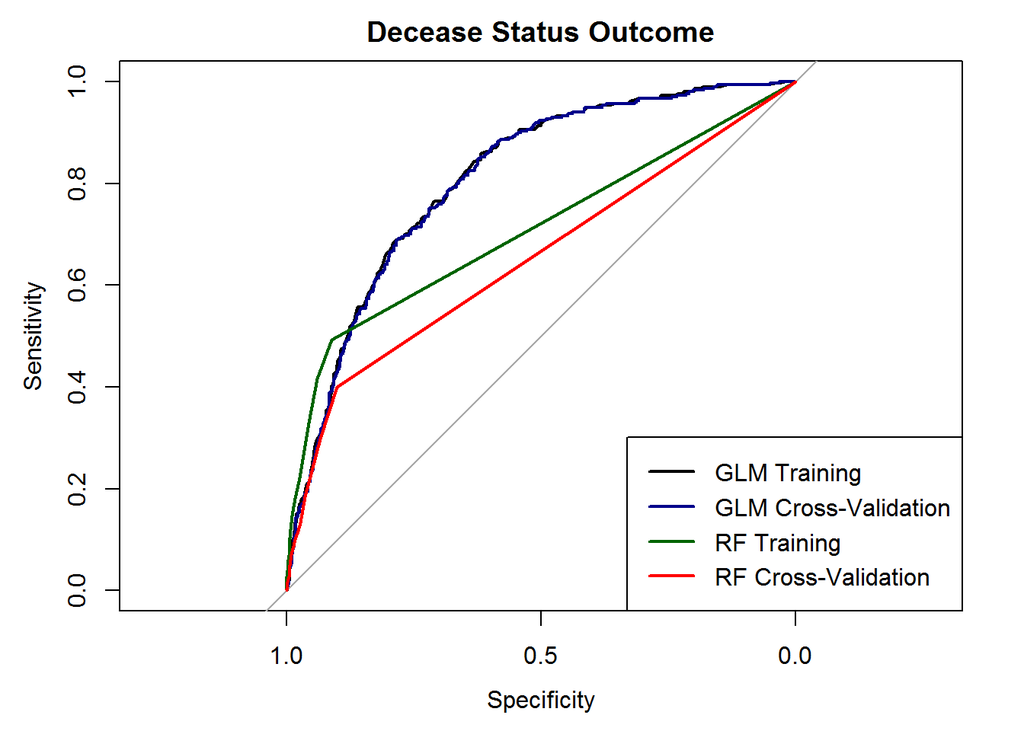

```r
rf.top.pred <- predict(rf.top, smoking_set, type = "prob")

#10-fold cross-validation
N = nrow(smoking_set)
K = 10
set.seed(1234)
s = sample(1:K, size = N, replace = T)
pred_outputs.glm <- vector(mode = "numeric", length = N)
pred_outputs.rf <- vector(mode = "numeric", length = N)
obs_outputs <- vector(mode = "numeric", length = N)
offset <- 0
for(i in 1:K){
    train <- filter(smoking_set, s != i)
    test <- filter(smoking_set, s == i)
    obs_outputs[1:length(s[s == i]) + offset] <- test$deceased.status
    #GLM train/test
    glm <- glm(deceased.status ~ age +smoking.status + race, data = train, family = binomial(logit))
    glm.pred.curr <- predict(glm, test, type = "response")
    pred_outputs.glm[1:length(s[s == i]) + offset] <- glm.pred.curr

    #RF train/test
    rf <- randomForest(deceased.status ~ age +smoking.status + race, data = train, ntree = 100)
    rf.pred.curr <- predict(rf, newdata = test, type = "prob")
    pred_outputs.rf[1:length(s[s == i]) + offset] <- rf.pred.curr[ , 2]

    offset <- offset + length(s[s == i])
}

#ROC Curves
library(pROC)
plot.roc(smoking_set$deceased.status, glm.top.pred, ci = TRUE, main = "Decease Status Outcome")
plot.roc(obs_outputs, pred_outputs.glm, ci = TRUE, col = "darkblue", add = TRUE)
plot.roc(smoking_set$deceased.status, rf.top.pred[, 2], ci = TRUE, col = "darkgreen", add = TRUE)
plot.roc(obs_outputs, pred_outputs.rf, ci = TRUE, col = "red", add = TRUE)
legend("bottomright", legend = c("GLM Training", "GLM Cross-Validation", "RF Training", "RF Cross-Validation"), col = c("black", "darkblue", "darkgreen", "red"), lwd = 2)
```

```r
auc(smoking_set$deceased.status, glm.top.pred)
```

```
## Area under the curve: 0.8087
```

```r
auc(obs_outputs, pred_outputs.glm)
```

```
## Area under the curve: 0.8057
```

```r
auc(smoking_set$deceased.status, rf.top.pred[ , 2])
```

```
## Area under the curve: 0.708
```

```r
auc(obs_outputs, pred_outputs.rf)
```

```
## Area under the curve: 0.6526
```

The ROC curve plots for ventilator use for both the models were shown below and AUROC was 0.652 on training data and 0.643 on 10-fold cross-validation for logistic regression and for RF they were 0.58 and 0.51 respectively.

```r
#FOR Ventilator
glm.top.pred <- predict(ventilator.glm, smoking_set, type = "response")

#Random Forest
library(randomForest)
rf.top <- randomForest(ventilator ~ age +gender + obesity, data = smoking_set,
                       ntree = 100, importance = TRUE)
rf.top
```

```
##
## Call:
##  randomForest(formula = ventilator ~ age + gender + obesity, data = smoking_set,      ntree = 100, importance = TRUE)
##                Type of random forest: classification
##                      Number of trees: 100
## No. of variables tried at each split: 1
##
##         OOB estimate of  error rate: 9.67%
## Confusion matrix:
##      N Y class.error
## N 2764 0           0
## Y  296 0           1
```

```r
rf.top$importance
```

```
##                     N             Y MeanDecreaseAccuracy MeanDecreaseGini
## age      3.172993e-04 -0.0011901904         1.705330e-04        15.921808
## gender  -1.916253e-05 -0.0001052304        -2.717336e-05         2.643125
## obesity  5.199010e-04 -0.0002204731         4.534979e-04         2.815702
```

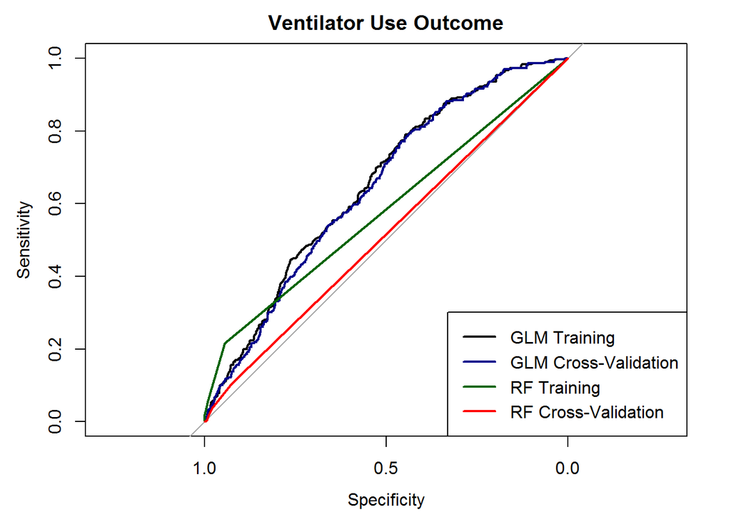

```r
rf.top.pred <- predict(rf.top, smoking_set, type = "prob")

#10-fold cross-validation
N = nrow(smoking_set)
K = 10
set.seed(1234)
s = sample(1:K, size = N, replace = T)
pred_outputs.glm <- vector(mode = "numeric", length = N)
pred_outputs.rf <- vector(mode = "numeric", length = N)
obs_outputs <- vector(mode = "numeric", length = N)
offset <- 0
for(i in 1:K){
    train <- filter(smoking_set, s != i)
    test <- filter(smoking_set, s == i)
    obs_outputs[1:length(s[s == i]) + offset] <- test$ventilator
    #GLM train/test
    glm <- glm(ventilator ~ age +gender + obesity, data = train, family = binomial(logit))
    glm.pred.curr <- predict(glm, test, type = "response")
    pred_outputs.glm[1:length(s[s == i]) + offset] <- glm.pred.curr

    #RF train/test
    rf <- randomForest(ventilator ~ age +gender + obesity, data = train, ntree = 100)
    rf.pred.curr <- predict(rf, newdata = test, type = "prob")
    pred_outputs.rf[1:length(s[s == i]) + offset] <- rf.pred.curr[ , 2]

    offset <- offset + length(s[s == i])
}

#ROC Curves
library(pROC)
plot.roc(smoking_set$ventilator, glm.top.pred, ci = TRUE, main = "Ventilator Use Outcome")
plot.roc(obs_outputs, pred_outputs.glm, ci = TRUE, col = "darkblue", add = TRUE)
plot.roc(smoking_set$ventilator, rf.top.pred[, 2], ci = TRUE, col = "darkgreen", add = TRUE)
plot.roc(obs_outputs, pred_outputs.rf, ci = TRUE, col = "red", add = TRUE)
legend("bottomright", legend = c("GLM Training", "GLM Cross-Validation", "RF Training", "RF Cross-Validation"), col = c("black", "darkblue", "darkgreen", "red"), lwd = 2)
```

```r
auc(smoking_set$ventilator, glm.top.pred)
```

```
## Area under the curve: 0.652
```

```r
auc(obs_outputs, pred_outputs.glm)
```

```
## Area under the curve: 0.6431
```

```r
auc(smoking_set$ventilator, rf.top.pred[ , 2])
```

```
## Area under the curve: 0.5811
```

```r
auc(obs_outputs, pred_outputs.rf)
```

```
## Area under the curve: 0.5149
```

On the training data and on 10-fold cross-validation the logistic regression for ICU admission, the AOCs were 0.625 and 0.617 where as for RF, the AOCs were 0.59 and 0.55 respectively and the curve plots were shown below.

```r
        #FOR ICU

glm.top.pred <- predict(icu.glm, smoking_set, type = "response")

#Random Forest
library(randomForest)
rf.top <- randomForest(icu ~ age +gender + obesity, data = smoking_set,
                       ntree = 100, importance = TRUE)
rf.top
```

```
##
## Call:
##  randomForest(formula = icu ~ age + gender + obesity, data = smoking_set,      ntree = 100, importance = TRUE)
##                Type of random forest: classification
##                      Number of trees: 100
## No. of variables tried at each split: 1
##
##         OOB estimate of  error rate: 12.94%
## Confusion matrix:
##      N Y class.error
## N 2664 0           0
## Y  396 0           1
```

```r
rf.top$importance
```

```
##                   N             Y MeanDecreaseAccuracy MeanDecreaseGini
## age     0.002981692 -1.109686e-03          0.002450745        15.792963
## gender  0.001319477 -6.198912e-04          0.001065265         2.167471
## obesity 0.002999321  5.544852e-05          0.002612959         3.577699
```

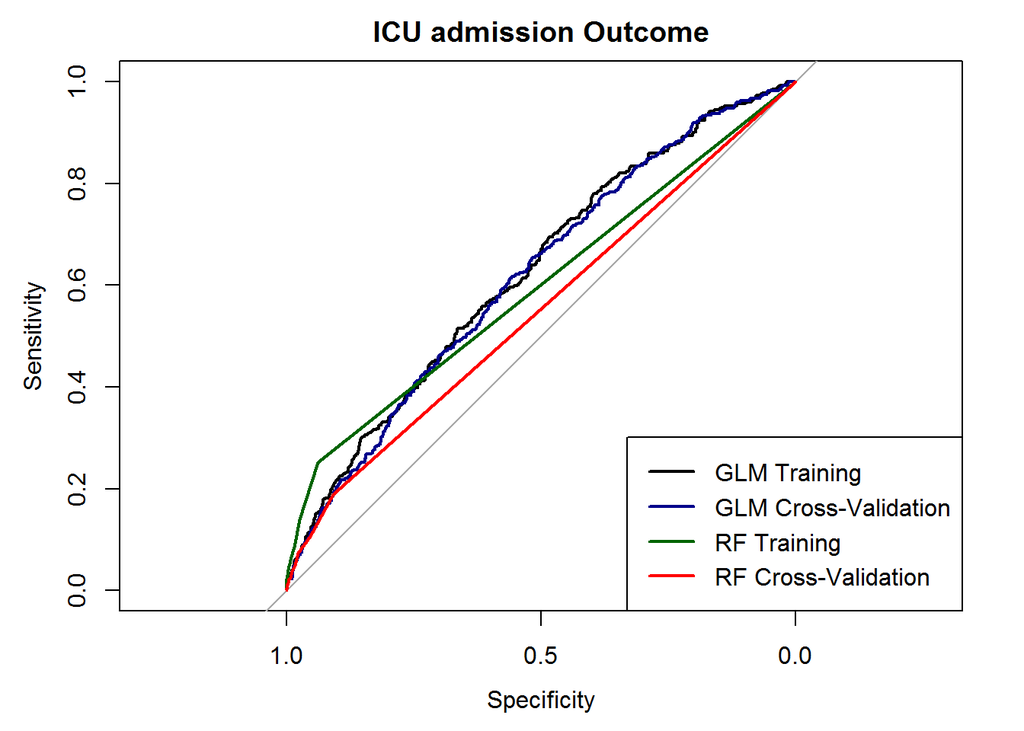

```r
rf.top.pred <- predict(rf.top, smoking_set, type = "prob")

#10-fold cross-validation
N = nrow(smoking_set)
K = 10
set.seed(1234)
s = sample(1:K, size = N, replace = T)
pred_outputs.glm <- vector(mode = "numeric", length = N)
pred_outputs.rf <- vector(mode = "numeric", length = N)
obs_outputs <- vector(mode = "numeric", length = N)
offset <- 0
for(i in 1:K){
    train <- filter(smoking_set, s != i)
    test <- filter(smoking_set, s == i)
    obs_outputs[1:length(s[s == i]) + offset] <- test$icu
    #GLM train/test
    glm <- glm(icu ~ age +gender + obesity, data = train, family = binomial(logit))
    glm.pred.curr <- predict(glm, test, type = "response")
    pred_outputs.glm[1:length(s[s == i]) + offset] <- glm.pred.curr

    #RF train/test
    rf <- randomForest(icu ~ age +gender + obesity, data = train, ntree = 100)
    rf.pred.curr <- predict(rf, newdata = test, type = "prob")
    pred_outputs.rf[1:length(s[s == i]) + offset] <- rf.pred.curr[ , 2]

    offset <- offset + length(s[s == i])
}

#ROC Curves
library(pROC)
plot.roc(smoking_set$icu, glm.top.pred, ci = TRUE, main = "ICU admission Outcome")
plot.roc(obs_outputs, pred_outputs.glm, ci = TRUE, col = "darkblue", add = TRUE)
plot.roc(smoking_set$icu, rf.top.pred[, 2], ci = TRUE, col = "darkgreen", add = TRUE)
plot.roc(obs_outputs, pred_outputs.rf, ci = TRUE, col = "red", add = TRUE)
legend("bottomright", legend = c("GLM Training", "GLM Cross-Validation", "RF Training", "RF Cross-Validation"), col = c("black", "darkblue", "darkgreen", "red"), lwd = 2)
```

```r
auc(smoking_set$icu, glm.top.pred)
```

```
## Area under the curve: 0.6253
```

```r
auc(obs_outputs, pred_outputs.glm)
```

```
## Area under the curve: 0.6177
```

```r
auc(smoking_set$icu, rf.top.pred[ , 2])
```

```
## Area under the curve: 0.5967
```

```r
auc(obs_outputs, pred_outputs.rf)
```

```
## Area under the curve: 0.55
```

### Conclusion:

This study has several limitations. The analysis was done from a single hospital system within a given geographic location thus I cannot be sure that we can apply to another region. Moreover, there were lots of missingness in the data such as other races and ethnicity information were missing. Only one comorbidity was used in this study to model the outcomes. Finally, a larger sample size would help us to determine whether the current variables used to model the outcomes were truly significant or not.

### About Peer feedback:

I agree somewhat with the first-round peers suggestions but with the data set I have, there are limitations.The basic aim and scope of this project is to see whether selective patient characteristics and selected comorbidities have had any impact on patients being on Ventilator or in ICU and any effects on mortality.

I do not have data on the admission and discharge times nor plans to see the extend care after discharge and as it is beyond the scope of this project.I have only very limited data points and that to they are discrete values of Yes/No.

The second report feedback suggestions were taken into consideration the race_wb issue was fixed. The socio-economic status variable was not available for us to add it to the analyses. Comments were added in the rmd file at the appropriate places and the sections were labeled properly.